# R Lightning Talk! @DSC 2015

Taste the power of Rcpp

Kyle Chung

Trend Micro, Data Scientist  
kylechun9@gmail.com

28 July, 2015

### What exactly is R?

```r
library(data.table)
library(stringr)

# download R source code if you dont have it yet
# download.file("http://cran.csie.ntu.edu.tw/src/base/R-3/R-3.2.1.tar.gz", "R-3.2.1.tar.gz")
# untar("R-3.2.1.tar.gz")

# get all file extensions in R source code
all_src_files <- list.files("./R-3.2.1/src/", recursive=TRUE, full.names=TRUE)
all_ext <- str_extract(all_src_files, "\\.[a-zA-Z]+$")
file_counts <- as.data.table(sort(table(all_ext), decreasing=TRUE), keep.rownames=TRUE)
```

### Distribution of source file counts in R

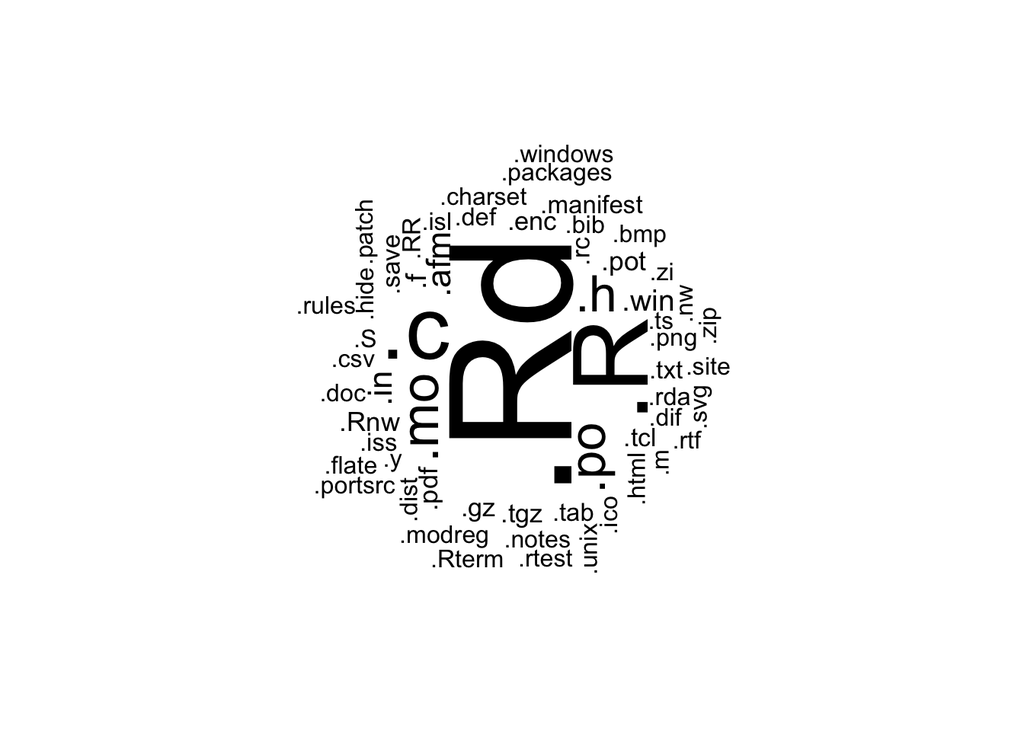

```r
library(wordcloud)
par(mar=c(0, 0, 0, 0))
wordcloud(file_counts$V1, file_counts$V2, min.freq=1, scale=c(7,1), rot.per=.35, random.order=F)
```

```r
library(ggvis)
file_counts[1:10] %>% ggvis(~reorder(V1, -V2), ~V2) %>% layer_bars() %>%
    add_axis('x', title="Source Type") %>% add_axis('y', title="File Count")
```

- Top-ten file types:
  - Rd: document file
  - **.R: R source**, of course
  - **.C: C source**
  - .mo: binary data file
  - .po: gettext file, about programming language translation
  - **.h: header file for C**
  - .afm: font file
  - .in: usually template config file for some macro preprocessor
  - .win: same above, but for Windows
  - **.f: Fortran source**

```r
# now focus on only source type files
src_ext <- c('c', 'h', 'R', 'f')
srcfiles <- list()
for ( ext in src_ext )
    srcfiles[[ext]] <- grep(sprintf("\\.%s$", ext), all_src_files, value=TRUE)
ext_dist <- sapply(srcfiles, length)
round(ext_dist / sum(ext_dist), 2)
```

```
##    c    h    R    f
## 0.37 0.15 0.46 0.02
```

As you can see, **R is heavily writen in C.** Indeed, most primitive functions are written in C code. Vectorization is implemented in C code. The speedy part of R is written in C. (And that’s why it is speedy.)

For example, `+` (the add function) is a primitive function written in C, vectorized.

```r
`+` # no R source code printed cause it is written in C
```

```
## function (e1, e2)  .Primitive("+")
```

In addition to distribution of *number of files* in R source, we can take a further look into the distribution of *number of lines* in each source type.

```r
# unix only
wc_res <- sapply(srcfiles, function(x)
    sum(as.integer(sapply(sprintf("wc -l < %s", x), system, intern=TRUE))))
round(wc_res / sum(wc_res), 2)
```

```
##    c    h    R    f
## 0.45 0.07 0.20 0.27
```

### Distribution of source line counts in R

```r
line_counts <- as.data.table(wc_res, keep.rownames=TRUE)
line_counts %>% ggvis(~rn, ~wc_res) %>% layer_bars() %>%
    add_axis('x', title="Source Type") %>% add_axis('y', title="Line Count", title_offset=60)
```

Finally, we’ve found that **only 20.09% of R source lines is written in R, and 45.2% of it is written by C, and 27.31% Fortran.**

### When R is not satisfying your need for speed…

- It’s simple. We can write R function in C/C++, which is usually above 10X faster than the equivalent of native R code.
- Okay. So **why not just use C/C++** for everything?
  - cause your *programming time* will explode to blow up all your potential performance gain, well, provided that you really can finish the analytic job purely in C++.
- This kind of high-level / low-level trade-off is happening in any modern analytic tools.
  - but at least you are capable of trading for such gain in R, which is a very flexible language for analytics.
  - for some other tools you simply CAN’T do anything to speed up your performance.

### But writing C/C++ for R is painful

- The traditional R API to C/C++ is talking like alien.

### Here comes `Rcpp`

- What is `Rcpp`?
  - A library for R (Eddelbuettel and Francois 2011) to build a more manageble API for integrating R and C++, so that users are more easy to write function in C++ to speed up their R program.
  - It provides *syntax sugar* so that the coding is less like C++ programing and more like R programing. Indeed it becomes something in-between.
- Useful resources:
  - [Rcpp Github page](https://github.com/RcppCore/Rcpp)
  - [Rcpp website](http://www.rcpp.org)

### Example 1: n-gram generation

Imagin you are dealing with hexdump of files and planning to use its n-gram frequency feature. Your input data may look like this:

```r
samplefile <- "index.html"
system(sprintf("xxd -g1 %s | head", samplefile), intern=TRUE) # unix only
```

```
##  [1] "0000000: 3c 21 44 4f 43 54 59 50 45 20 68 74 6d 6c 3e 0a  <!DOCTYPE html>."
##  [2] "0000010: 0a 3c 68 74 6d 6c 20 78 6d 6c 6e 73 3d 22 68 74  .<html xmlns=\"ht"
##  [3] "0000020: 74 70 3a 2f 2f 77 77 77 2e 77 33 2e 6f 72 67 2f  tp://www.w3.org/"
##  [4] "0000030: 31 39 39 39 2f 78 68 74 6d 6c 22 3e 0a 0a 3c 68  1999/xhtml\">..<h"
##  [5] "0000040: 65 61 64 3e 0a 0a 3c 6d 65 74 61 20 63 68 61 72  ead>..<meta char"
##  [6] "0000050: 73 65 74 3d 22 75 74 66 2d 38 22 3e 0a 3c 6d 65  set=\"utf-8\">.<me"
##  [7] "0000060: 74 61 20 68 74 74 70 2d 65 71 75 69 76 3d 22 43  ta http-equiv=\"C"
##  [8] "0000070: 6f 6e 74 65 6e 74 2d 54 79 70 65 22 20 63 6f 6e  ontent-Type\" con"
##  [9] "0000080: 74 65 6e 74 3d 22 74 65 78 74 2f 68 74 6d 6c 3b  tent=\"text/html;"
## [10] "0000090: 20 63 68 61 72 73 65 74 3d 75 74 66 2d 38 22 20   charset=utf-8\" "
```

We firstly tidy the input to be a long character sequence…

```r
hexdumplines <- system(sprintf("xxd -g1 %s | cut -d \" \" -f 2-17", samplefile), intern=TRUE) # unix only
hexdump <- unlist(strsplit(paste(hexdumplines, collapse=' '), ' '))
hexdump <- hexdump[hexdump != '']
str(hexdump)
```

```
##  chr [1:1780975] "3c" "21" "44" "4f" "43" "54" "59" "50" "45" "20" "68" "74" "6d" "6c" ...
```

Then what? Try looping in native R code, which is rather straight forward.

```r
# first trial: use native R loop (could be terrible for large-scale processing...)
generateNgramFreqR <- function(x, n) {
    len <- length(x) - (n - 1)
    out <- character(len) # pre-allocate size, very important
    for ( i in 1:len ) {
        out[i] <- x[i]
        if ( n > 1 )
            for ( j in 1:(n-1) )
                out[i] <- paste0(out[i], x[i+j])
    }
    unlist(as.list(sort(table(out), decreasing=TRUE)))
}
system.time(r_res <- generateNgramFreqR(hexdump, 2))
```

```
##    user  system elapsed
##  11.452   0.231  12.246
```

```r
r_res[1:10]
```

```
##   2532   2533   3245   4141   3243   3230   3239   3238   2537   3925
## 140886  38566  23687  21677  20037  18886  18817  18718  18242  17731
```

Or we can use some external library that focuses on text mining, for example, use `tau` (Buchta et al. 2015).

```r
# second trial: use external library
generateNgramFreqTau <- function(x, n) {
    require(tau)
    tau_res <- textcnt(x, n=n, method="string", split="[[:space:]]+")
    names(tau_res) <- gsub(' ', '', names(tau_res))
    sort(tau_res, decreasing=TRUE)
}
system.time(tau_res <- generateNgramFreqTau(hexdump, 2))
```

```
##    user  system elapsed
##   7.656   0.213   7.960
```

```r
tau_res[1:10]
```

```
##   2532   2533   3245   4141   3243   3230   3239   3238   2537   3925
## 140886  38566  23687  21677  20037  18886  18817  18718  18242  17731
```

```r
# check if the results are eqaul
identical(tau_res, r_res)
```

```
## [1] TRUE
```

But the performance of the above two solutions are both not satisfying when it comes to large-scale problem. Think about dealing with hex-dump strings from tens of thousands of files, we will need more efficient solution.

Sometimes to make things better all you have to do is to find ANOTHER package that is more powerful over the probelm at hand. But still sometimes you just don’t have much to choose. In this very case of generating n-grams, though there is another well-known general text mining pacakge `tm` (Feinerer and Hornik 2015; Feinerer, Hornik, and Meyer 2008) available, it is not suitable to serve as a faster solution to our problem. Indeed, it is prohibitively slow.

```r
# third trial: use another external library, hopefully faster? (Nope.)
generateNgramFreqTm <- function(x, n) {
    require(tm)
    op <- options(mc.cores=NULL)
    options(mc.cores=1)
    on.exit(options(op))

    ngramTokenizer <- function(x) RWeka::NGramTokenizer(x, RWeka::Weka_control(min=2, max=2))
    corp <- Corpus(VectorSource(paste(x, collapse=' ')))
    tdm <- TermDocumentMatrix(corp, control=list(tokenize=ngramTokenizer))
    res <- rowSums(as.matrix(tdm))
    names(res) <- gsub(' ', '', names(res))
    sort(res, decreasing=TRUE)
}

# full-size input not run, too slow
length(hexdumplines)
```

```
## [1] 111311
```

```r
system.time(tm_res <- generateNgramFreqTm(hexdumplines[1:10000], 2))
```

```
##    user  system elapsed
##  14.295   0.271  14.643
```

```r
tm_res[1:10]
```

```
##  2532  2533  3239  3238  3243  3245  3344  4425  3925  2537
## 21069  6151  3534  3533  3529  3479  3464  3354  3248  3204
```

Let’s try `Rcpp` to see what we could further achieve.

```r
# final trial: use Rcpp to write the function in C++
library(Rcpp)
cppFunction('
    CharacterVector generateNgramFreq (CharacterVector hexvector, int ngram) {
        int len = hexvector.size() - (ngram - 1);
        CharacterVector out(len);
        for (int i = 0; i < len; i++) {
            out(i) = hexvector[i];
            for (int j = 1; j < ngram; j++) {
                out(i) += hexvector[i+j];
            }
        }
        return out;
    }')
generateNgramFreq
```

```
## function (hexvector, ngram)
## .Primitive(".Call")(<pointer: 0x10b559510>, hexvector, ngram)
```

```r
generateNgramFreqCpp <- function(x, n)
    unlist(as.list(sort(table(generateNgramFreq(x, n)), decreasing=TRUE)))
system.time(cpp_res <- generateNgramFreqCpp(hexdump, 2))
```

```
##    user  system elapsed
##   0.396   0.045   0.442
```

```r
cpp_res[1:10]
```

```
##   2532   2533   3245   4141   3243   3230   3239   3238   2537   3925
## 140886  38566  23687  21677  20037  18886  18817  18718  18242  17731
```

```r
identical(cpp_res, r_res)
```

```
## [1] TRUE
```

Now it’s time to benchmark these solutions to see the performance difference. You’ll see that the `Rcpp` solution is above **10X faster** than its alternatives. Depends on the scale of your problem such gap could be further enlarged.

```r
library(microbenchmark)
microbenchmark(generateNgramFreqR(hexdump, 2),
               generateNgramFreqTau(hexdump, 2),
               generateNgramFreqCpp(hexdump, 2),
               times=10)
```

```
## Unit: milliseconds
##                              expr       min         lq       mean     median         uq        max neval
##    generateNgramFreqR(hexdump, 2) 9706.8352 10054.8189 10419.5566 10532.4037 10725.8482 11177.2476    10
##  generateNgramFreqTau(hexdump, 2) 6125.0972  7266.1923  7515.5358  7630.1056  7925.4634  8134.4764    10
##  generateNgramFreqCpp(hexdump, 2)  416.7993   453.6783   614.8183   599.8169   746.5086   907.3503    10
```

- Interested? See the [Microsoft malware classification challenge](https://www.kaggle.com/c/malware-classification)

### Example 2: moving-window computing

Move on to the next case. Suppose you’d like to monitor the system logs in your computer, counting the process that triggers logging in a sliding-window manner.

```r
syslogname <- "system.log" # this is for Mac, for Linux you may use "syslog" instead
syslogs <- grep(syslogname, dir("/var/log", full.names=TRUE), value=TRUE)
loglines <- unlist(lapply(syslogs,
                          function(x) {
                              con <- gzfile(x)
                              on.exit(close(con))
                              readLines(con)
                          }))
head(loglines)
```

```
## [1] "Jul 28 00:06:40 kyledembpr kernel[0]: Previous sleep cause: 5"
## [2] "Jul 28 00:06:40 kyledembpr kernel[0]: The USB device Card Reader (Port 3 of Hub at 0x15000000) may have caused a wake by being disconnected"
## [3] "Jul 28 00:06:40 kyledembpr.client.tw.trendnet.org discoveryd[635]: Basic DNSResolver UDNSServer:: PowerState is DarkWake"
## [4] "Jul 28 00:06:40 kyledembpr kernel[0]: AppleThunderboltNHIType2::prePCIWake - power up complete - took 64307 us"
## [5] "Jul 28 00:06:40 kyledembpr kernel[0]: AppleThunderboltGenericHAL::earlyWake - complete - took 14 milliseconds"
## [6] "Jul 28 00:06:40 kyledembpr kernel[0]: IOThunderboltSwitch<0xffffff8025614c00>(0x0)::listenerCallback - Thunderbolt HPD packet for route = 0x0 port = 11 unplug = 0"
```

Here we use regex to extract fields we are intereted, convert datetime character to POSIX time object, and take a look at the top distributed categories of process names.

```r
logdat <- as.data.table(str_match(loglines, "(^.*[0-9]+ [0-9]{2}:[0-9]{2}:[0-9]{2})([^:]+:)")[,2:3])
setnames(logdat, c("ts", "cate"))
logdat[, `:=`(cate=str_match(cate, " ([a-zA-Z]+)\\[[0-9]+\\]")[,2],
              ts=as.POSIXct(ts, format="%b %e %H:%M:%S"))]
logdat[, tsint:=as.integer(ts)]
logdat <- logdat[!is.na(cate)]
setorder(logdat, ts)
logdat
```

```
##                         ts           cate      tsint
##     1: 2015-07-21 00:00:01 SubmitDiagInfo 1437408001
##     2: 2015-07-21 00:00:05         powerd 1437408005
##     3: 2015-07-21 00:00:05   WindowServer 1437408005
##     4: 2015-07-21 00:00:05   WindowServer 1437408005
##     5: 2015-07-21 00:00:10         powerd 1437408010
##    ---
## 19360: 2015-07-28 11:18:55           Dock 1438053535
## 19361: 2015-07-28 11:18:56           Dock 1438053536
## 19362: 2015-07-28 11:18:56           Dock 1438053536
## 19363: 2015-07-28 11:18:56           Dock 1438053536
## 19364: 2015-07-28 11:18:56           Dock 1438053536
```

```r
sort(table(logdat$cate), decreasing=TRUE)[1:10]
```

```
##
##                       Dock                     kernel               WindowServer                 discoveryd
##                       9081                       2742                       1618                       1339
##                   sharingd             storedownloadd GoogleSoftwareUpdateDaemon                       Book
##                        632                        585                        364                        337
##              nsurlstoraged              CalendarAgent
##                        287                        240
```

Suppose the task is to count number of records for each process within the last 5 minutes for every 1 minute. This is a moving-window operation which could be painful should you use pure R code to solve it. Of course there are dedicated packages aiming at this kind of task but again for this very case none of them to my best knowledge could work efficently.

```r
# first trial: again, naive approach first
movingWindowCountR <- function(DT, wsize, interval, select=NULL) {
    require(data.table)
    sts <- min(DT$tsint)
    ninter <- ceiling(diff(range(DT$tsint)) / interval)
    if ( !is.null(select) )
        DT <- DT[cate %in% select]
    res <- list()
    for ( ca in unique(DT$cate) ) {
        sts_ <- sts
        cnt <- integer(ninter)
        for ( i in 1:ninter ) {
            cnt[i] <- nrow(DT[cate == ca][tsint <= sts_ & tsint > sts_ - wsize])
            sts_ <- sts_ + interval
        }
        res[[ca]] <- cnt
    }
    res
}
# run for only two processess cause to slow...
system.time(r_res <- movingWindowCountR(logdat, 300, 60, c("kernel", "discoveryd")))
```

```
##    user  system elapsed
##  32.629   0.679  34.034
```

Let’s plot the moving-window-count time series for process “kernel”.

```r
kernel_mvcnt <- data.table(count=r_res[["kernel"]])
kernel_mvcnt[, t:=1:.N]
kernel_mvcnt %>% ggvis(~t, ~count) %>% layer_lines()
```

The bottleneck is, of course, at the loop code. R is not good at explicit looping. When you just don’t find a way to avoid coding like this, it is probably a strong sign indicating the use of `Rcpp`.

But before that, let’s struggle a little bit more.

```r
# second trial: play tricky
movingWindowCountR2 <- function(DT, wsize, interval, select=NULL) {
    require(data.table)
    wsize <- wsize
    allts <- data.table(tsint=min(DT$tsint):max(DT$tsint))
    if ( !is.null(select) )
        DT <- DT[cate %in% select]
    res <- lapply(split(DT, DT$cate),
                  function(x) {
                      x <- merge(x, allts, by="tsint", all=TRUE)
                      tsunit_cnt <- x[, list(cnt=sum(!is.na(cate))), by="tsint"]
                      tsunit_cumcnt <- c(rep(0, wsize), cumsum(tsunit_cnt$cnt))
                      as.integer(tail(tsunit_cumcnt, -wsize) - head(tsunit_cumcnt, -wsize))
                  })
    lapply(res, function(x) x[seq(1, length(x), interval)])
}

# run for all processes
system.time(r2_res <- movingWindowCountR2(logdat, 300, 60))
```

```
##    user  system elapsed
##  63.921   4.575  70.119
```

```r
identical(r_res[["kernel"]], r2_res[["kernel"]])
```

```
## [1] TRUE
```

Our second solution is considerably faster, though little bit harder to code and maintain. What if we simply re-write the loop in the first solution in `Rcpp`?

```r
# final trial
cppFunction('
    NumericVector movingWindowCount(NumericVector ts, int wsize, int interval, int sts, int nt) {
        NumericVector out(nt);
        for (int i = 0; i < nt; i++) {
            NumericVector cnts = ts[(ts <= sts) & (ts > sts - wsize)];
            out(i) = cnts.size();
            sts += interval;
        }
        return out;
    }')

movingWindowCountCpp <- function(DT, wsize, interval, select=NULL) {
    require(data.table)
    sts <- min(DT$tsint)
    ninter <- ceiling(diff(range(DT$tsint)) / interval)
    if ( !is.null(select) )
        DT <- DT[cate %in% select]
    lapply(split(DT, DT$cate),
           function(x) as.integer(movingWindowCount(x$ts, wsize, interval, sts, ninter)))
}

# run for all processes
system.time(rcpp_res <- movingWindowCountCpp(logdat, 300, 60))
```

```
##    user  system elapsed
##   5.337   0.349   5.780
```

```r
identical(rcpp_res[["kernel"]], r_res[["kernel"]])
```

```
## [1] TRUE
```

```r
length(rcpp_res)
```

```
## [1] 86
```

```r
xargs <- list(logdat, 300, 60, c("kernel", "discoveryd"))
microbenchmark(do.call(movingWindowCountR, xargs),
               do.call(movingWindowCountR2, xargs),
               do.call(movingWindowCountCpp, xargs),
               times=3)
```

```
## Unit: seconds
##                                  expr       min        lq      mean    median        uq       max neval
##    do.call(movingWindowCountR, xargs) 35.646060 35.828431 36.963566 36.010802 37.622318 39.233835     3
##   do.call(movingWindowCountR2, xargs)  1.466984  1.593590  1.680163  1.720196  1.786753  1.853309     3
##  do.call(movingWindowCountCpp, xargs)  1.101173  1.115042  1.122784  1.128911  1.133590  1.138268     3
```

```r
allcate <- unique(logdat$cate)
nround <- 20
elapsed_r2 <- numeric(nround)
elapsed_rcpp <- numeric(nround)
for ( i in 1:nround ) {
    xargs <- list(logdat, 300, 60, allcate[1:i])

    stime <- proc.time()
    do.call(movingWindowCountR2, xargs)
    elapsed_r2[i] <- (proc.time() - stime)["elapsed"]

    stime <- proc.time()
    do.call(movingWindowCountCpp, xargs)
    elapsed_rcpp[i] <- (proc.time() - stime)["elapsed"]
}
```

```r
bres <- rbind(data.table(n=1:nround, t=elapsed_r2, alg="r2"),
              data.table(n=1:nround, t=elapsed_rcpp, alg="rcpp"))
bres %>% ggvis(~n, ~t, fill=~alg) %>% layer_points() %>%
    add_axis('x', title="nround") %>% add_axis('y', title="Seconds Elapsed")
```

- See [Rcpp sugar](http://dirk.eddelbuettel.com/code/rcpp/Rcpp-sugar.pdf) introduction to discover more tips about writing `Rcpp` functions.

### Example 3: ad-hoc data.frame operation

There are other cases that you found solutions of existing packages lacking efficiency. That’s assume an MOOC-like student-course activity log in a simplist format. We log all activities for all students in all courses with timestamp. (Assume 26 courses in total, marked by English letters. Students are indexed by incremental integers.)

```r
# generate a simulated data as our playground
genSimData <- function(nlog, nuser, seed) {
    set.seed(seed)
    dat <- data.table(user=sample(1:nuser, nlog, replace=TRUE,
                                  prob=rbeta(1:nuser, .1, 2)),
                      course=sample(letters, nlog, replace=TRUE, prob=1:26),
                      ts=runif(nlog, as.integer(as.POSIXct("2015-01-01")),
                               as.integer(as.POSIXct("2015-06-30"))))
    dat[, t:=as.POSIXct(ts, origin="1970-01-01")]
    setorder(dat, user, course, ts)
    dat
}

simlog <- genSimData(nlog=1e6, nuser=1e3, seed=528491)
head(simlog)
```

```
##    user course         ts                   t
## 1:    2      a 1420055427 2015-01-01 03:50:26
## 2:    2      a 1420219054 2015-01-03 01:17:33
## 3:    2      a 1420320164 2015-01-04 05:22:44
## 4:    2      a 1421227260 2015-01-14 17:21:00
## 5:    2      a 1421467857 2015-01-17 12:10:57
## 6:    2      a 1422182483 2015-01-25 18:41:22
```

Now based on such dataset, assume we’d like to extract a feature: *How many courses in total did a student register at the time of his/her last activity record for each course*? For example, if student 1’s last activity for course a is today, then how many courses in total (including course a) did she also have at least one activity records?

This problem requires a some-how twisted by-group operation on data.frame, and hence could be challenging if the scale is huge.

```r
# naive apporach first
adHocOperateR <- function(DT) {
    require(data.table)
    DT <- copy(DT)
    DT[, `:=`(tsmin=min(ts), tsmax=max(ts)), by="user,course"]
    DT <- unique(DT[, list(user, course, tsmin, tsmax)])
    res <- integer()
    for ( i in unique(DT$user) ) {
        tmpdat <- DT[user == i]
        for ( j in tmpdat$course ) {
            res <- c(res, sum(tmpdat$tsmin <= tmpdat[course == j, tsmax]))
        }
    }
    cbind(DT[, list(user, course)], res)
}

system.time(res_r1 <- adHocOperateR(simlog))
```

```
##    user  system elapsed
##  10.231   0.142  10.555
```

```r
res_r1[sample(nrow(res_r1), 10)]
```

```
##     user course res
##  1:  658      z  25
##  2:  386      q  26
##  3:  504      y  24
##  4:  481      p  15
##  5:  284      j  26
##  6:  184      q  26
##  7:  629      k  26
##  8:  884      d  26
##  9:  118      k  25
## 10:  320      b  26
```

The naive approach scales well in `nlog` but not in `nuser` cause the latter impacts how many loops actually run in our solution. Relying only on `data.table`, can we improve? The anwser is yes. The following solution use the so-called *“grouping by each i”* technique to drastically improve performance.

```r
# let's utilizing data.table bitter
adHocOperateR2 <- function(DT) {
    require(data.table)
    DT <- copy(DT)
    DT[, `:=`(tsmin=min(ts), tsmax=max(ts)), by="user,course"]
    tmpdat1 <- unique(DT[, list(user, course, tsmin)])
    tmpdat2 <- unique(DT[, list(user, course, tsmax)])
    setkey(tmpdat1, user)
    setkey(tmpdat2, user)
    cbind(tmpdat1[, list(user, course)],
          res=tmpdat1[tmpdat2, list(res=sum(tsmin <= tsmax)), by=.EACHI][, res])
}
system.time(res_r2 <- adHocOperateR2(simlog))
```

```
##    user  system elapsed
##   0.120   0.024   0.145
```

```r
setkey(res_r1, user)
identical(res_r1, res_r2)
```

```
## [1] TRUE
```

Time for `Rcpp`. Is it possible to be even faster?

```r
cppFunction('
    NumericVector adHocOperate (NumericVector first, NumericVector last) {
        int len = first.size();
        NumericVector out(len);
        for (int i = 0; i < len; i++) {
            out(i) = 0;
            for (int j = 0; j < len; j++) {
                if (first(j) <= last(i)) {
                    out(i) += 1;
                }
            }
        }
        return out;
    }')

adHocOperateCpp <- function(DT) {
    require(data.table)
    DT <- copy(simlog)
    DT[, `:=`(tsmin=min(ts), tsmax=max(ts)), by="user,course"]
    DT <- unique(DT[, list(user, course, tsmin, tsmax)])
    cbind(DT[, list(user, course)],
          res=as.integer(DT[, list(res=adHocOperate(.SD$tsmin, .SD$tsmax)), by="user"][, res]))
}

system.time(res_cpp <- adHocOperateCpp(simlog))
```

```
##    user  system elapsed
##   0.102   0.012   0.116
```

```r
setkey(res_cpp, user)
identical(res_cpp, res_r1)
```

```
## [1] TRUE
```

Well, the result suggests that `Rcpp` solution performs fairly equal to the `data.table` solution. Time to inspect the scalability issue.

```r
# make the data bigger
simlog <- genSimData(nlog=1e7, nuser=1e4, seed=528491)
microbenchmark(adHocOperateR2(simlog),
               adHocOperateCpp(simlog),
               times=10)
```

```
## Unit: seconds
##                     expr      min       lq     mean   median       uq      max neval
##   adHocOperateR2(simlog) 1.515727 1.594130 1.658769 1.667782 1.712563 1.821021    10
##  adHocOperateCpp(simlog) 1.263045 1.344909 1.513549 1.562751 1.600723 1.666989    10
```

Finally, the `Rcpp` solution still outperforms, but not in so much advantage. The `data.table` solution did a fairly good job. The reason is not surprising: `data.table` itself is largely written in C.

Here is the take-a-way from the 3rd example: when performance is the key factor in your computing job and you find yourself facing severe performance bottleneck, you either rewrite the key operaion part of your code in `Rcpp` or you choose a package that is written in C and hopefully can solve your problem. To be a more independent data analyst, it is really worth learning `Rcpp`. As you can see in the above three examples, sometimes it only takes a little simple coding and your task will be done in lightning fast.

### Appendix

References

Buchta, Christian, Kurt Hornik, Ingo Feinerer, and David Meyer. 2015. *Tau: Text Analysis Utilities*. http://CRAN.R-project.org/package=tau.

Dowle, M, T Short, S Lianoglou, A Srinivasan with contributions from R Saporta, and E Antonyan. *Data.table: Extension of Data.frame*. https://github.com/Rdatatable/data.table/wiki.

Eddelbuettel, Dirk, and Romain Francois. 2011. “Rcpp: Seamless R and C++ Integration.” *Journal of Statistical Software* 40 (8): 1–18. http://www.jstatsoft.org/v40/i08.

Feinerer, Ingo, and Kurt Hornik. 2015. *Tm: Text Mining Package*. http://CRAN.R-project.org/package=tm.

Feinerer, Ingo, Kurt Hornik, and David Meyer. 2008. “Text Mining Infrastructure in R.” *Journal of Statistical Software* 25 (5): 1–54. http://www.jstatsoft.org/v25/i05/.

Hornik, Kurt, Christian Buchta, and Achim Zeileis. 2009. “Open-Source Machine Learning: R Meets Weka.” *Computational Statistics* 24 (2): 225–32. doi:10.1007/s00180-008-0119-7.

Wickham, Hadley. 2015. *Stringr: Simple, Consistent Wrappers for Common String Operations*. http://CRAN.R-project.org/package=stringr.